# Population characteristics of the Pacific giant salamander in old growth vs clear cut forests

Cori Lopazanski, Kai Kopecky

11/22/2019

### Introduction

Amphibian populations have been declining for over half a century<sup>1</sup>, with more than 32% of global populations currently threatened<sup>2</sup>. Habitat loss and fragmentation are among the biggest threats to these fragile populations, which require particular temperatures and levels of moisture to survive<sup>3</sup>. Clear-cut logging, in particular, has been shown to increase sedimentation in streams, which negatively impacts larval amphibians<sup>3</sup>. Monitoring efforts have been implemented to assess how activities like clear-cutting affect salmonid populations, including the Aquatic Vertebrate Population Study within the H.J. Andrews Forest Long Term Ecological Research Program (HJA LTER), which monitors the threatened Pacific giant salamander (*Dicamptodon tenebrosus*) among other species. Here, we examine the distribution of Pacific giant salamanders in a section of forest that was clear-cut for logging in 1963 compared to a nearby 500 year old coniferous forest in Mack Creek, Oregon. Restoration efforts are sometimes used to attempt to convert habitats from a degraded state back to their pre-disturbance condition, typically by creating pools or increasing habitat complexity<sup>4</sup>. Understanding how the distribution of Pacific giant salamanders changes in different habitats can help guide restoration efforts.

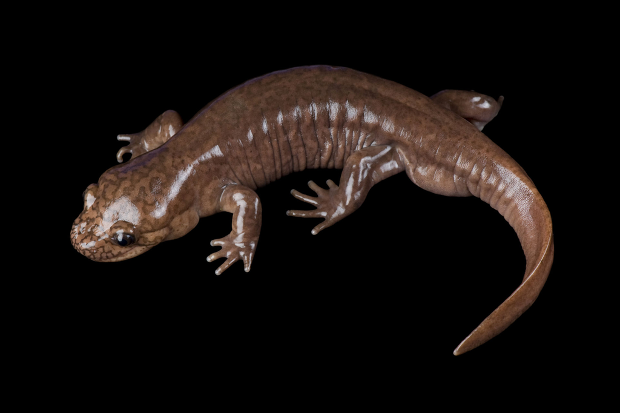

*Figure 1.* Pacific giant salamander, *Dicamptodon tenebrosus*. Photographer: Joel Sartore, National Geographic Photographer ([source](https://www.joelsartore.com/ani067-00279/))

[video not shown]

*Figure 2.* Video of Pacific giant salamander. These are some of the only amphibians known to make vocalizations. Provided by YouTube user: MFWestphal ([source](https://youtu.be/mmm1Ml4sHE4))

### Data and Methods

As part of an effort to monitor population trends of aquatic vertebrates in the H.J. Andrews Experimental Forest, data on annual abundances, weights, forest section location, and habitat preferences of the Pacific giant salamander have been collected by researchers with the Andrews Forest Long Term Ecological research site since 1993<sup>5</sup>. Mack Creek runs through sections of both old growth and historically clear-cut forest and provides three primary types of habitat for aquatic organisms (pools, side-channels, and cascades). 150m stretches of the creek are divided into contiguous 50m sections, which were netted at each end. Observations for aquatic vertebrates were acquired via two-pass electrofishing, followed by subsequent measurement of body dimensions and weight for all captured individuals.

We compared annual abundances from 1993 - 2017, and habitat preferences and weight differences in 2017 for Pacific giant salamanders in old growth and clear cut sections of forest. We used a Chi-square test to assess salamander habitat preferences within forest sections, a two-sample t-test to compare mean weights by forest section, and a one-way ANOVA to compare mean weights of salamanders across the three primary habitat types. For all statistical tests, we used a significance level of $\alpha$ = 0.05. All data preparation and analyses were completed using R software (version 3.6.1) and RStudio (version 1.2.5001).

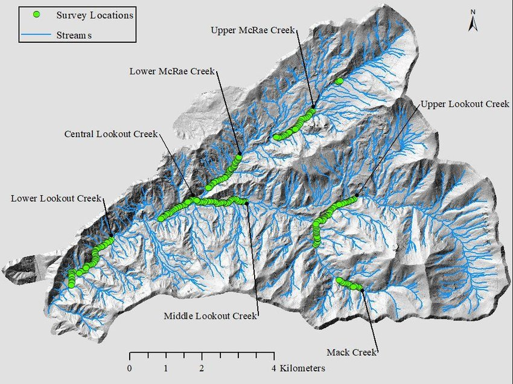

*Figure 3.* Map of H. J. Andrews Experimental Forest with associated streams. Streams are depicted as blue lines and sample locations as green circles. This report focuses on salamanders found in Mack Creek. Picture credit: Sashka Warner. ([source](https://www.researchgate.net/publication/324601050_Interactions_of_Roads_and_Deforestation_with_Stream_Sediment_Size_and_Network_Structure_in_the_Western_Cascade_Range_of_Oregon/figures?lo=1))

### Results

#### Pacific giant salamander abundance over time

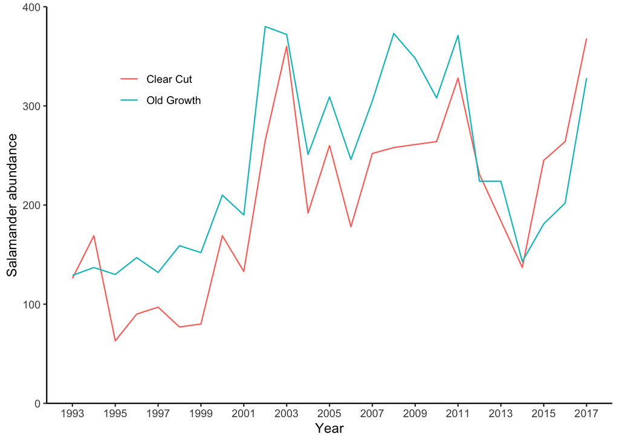

*Figure 4.* *Annual abundances of the Pacific giant salamander in two standard reaches of Mack Creek in the H. J. Andrews Experimental Forest from 1993 -2017. Salamanders were counted in a reach running through a section of old growth forest (blue line) and a section of historically clear-cut forest (red line).*

#### Salamander habitat preference within old growth vs clear cut forest sections

| Table 1: Proportions of giant salamanders in different channel classifications observed in two sections of Mack Creek | Table 1: Proportions of giant salamanders in different channel classifications observed in two sections of Mack Creek Clear Cut | Table 1: Proportions of giant salamanders in different channel classifications observed in two sections of Mack Creek Old Growth |
| --- | --- | --- |
| Cascade | 247 (67.1%) | 201 (62.8%) |
| Pool | 31 (8.4%) | 45 (14.1%) |
| Side-Channel | 90 (24.5%) | 74 (23.1%) |

Channels that make up Pacific giant salamander habitat are often classified into three different areas: cascades, pools, and side channels. Proportions of salamanders in each channel classification were compared for the old growth and clear cut sections of Mack Creek (Table 1).

There is not a significant effect of forest section (old growth or clear cut) on where salamanders are found in the channel ($\chi$<sup>2</sup>(2) = 5.54, p = 0.06). There are similar proportions of salamanders found in each of the three channel classifications in both the clear-cut and old growth sections of forest (Table 1).

#### Comparison of salamander weight by forest section and channel classification

In addition to abundance, examining salamander weight can yield more information about the size distribution of the populations in the different forest sections and channel classifications.

There was no significant difference in mean salamander weight in 2017 for the old growth compared to the clear cut section of forest (two sample t-test, t(692.79) = -1.67, *p* = 0.096). Thus, weight information was combined for the two sections to examine size distributions across the diffferent channel classifications (Figure 5).

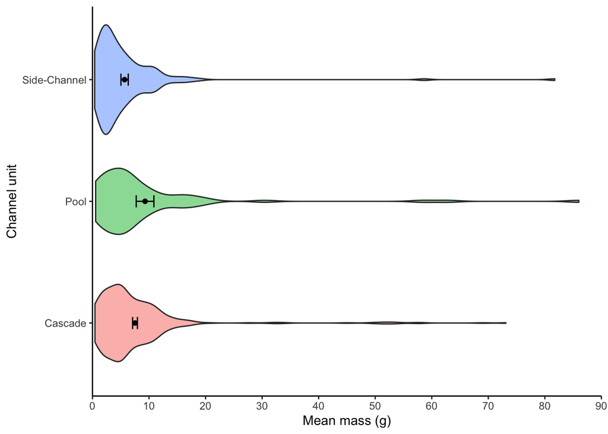

*Figure 5.* *Distributions for Giant Pacific Salamander mass (g) are displayed (violins) for habitat type, pooled for old growth and clear cut sections of forest. Mean masses (black dots) $\pm$ standard error (error bars) are displayed for each habitat type.*

Mean weights of Pacific giant salamanders did differ significantly between pools and side channels (one-way ANOVA with post-hoc Tukey’s HSD: F$_{2,684}$ = 4.22, *p* = 0.015). Mean weights for individuals from cascades did not differ significantly from the other two habitat types (Figure 5). The average weight for populations residing in pools (9.3 $\pm$ 1.56 g) was 63.79% more than that of populations observed in side-channels (5.68 $\pm$ 0.65 g). Due to large within group variation of salamander weights in each habitat type, an alternative metric – population medians, for instance – may lend to a more meaningful and accurate comparison across these groups. This could be achieved by using a rank-based test, such as a Mann-Whitney U test.

### Summary

- From 1993-2017, overall Pacific giant salamander abundances increased in both old growth and historically clear cut sections of forest, by 154% and 192% respectively (Figure 4).
- Forest section (old growth vs clear cut) did not significantly affect the habitat type (pool, cascade, or side-channel) in which salamnders were found (Table 1).
- There is no significant difference in mean salamander weight in 2017 for the old growth compared to the clear cut section of forest.
- In 2017, the mean weight of salamanders residing in pools was significantly greater than that of populations in side channels (Figure 5).

### References

1. Houlahan, J., et al. “Quantitative evidence for global amphibian population declines.” Nature 404 (2000): 752-755.
2. Stuart, S. N., et al. “Status and trends of amphibian declines and extinctions worldwide.” Science 306 (2004): 1783-1786.
3. Johnston, B. and Frid, L. “Clearcut logging restricts the movements of terrestrial Pacific giant salamanders (Dicamptodon tenebrosus Good)” Canadian Journal of Zoology 80 (2011): 2170-2177.
4. Roni, P. “Habitat use by fishes and pacific giant salamanders in small western Oregon and Washington streams.” Transactions of the American Fisheries Society 131.4 (2002): 743-761.
5. Gregory S. V. 2016. Aquatic Vertebrate Population Study in Mack Creek, Andrews Experimental Forest, 1987 to present. Environmental Data Initiative. https://doi.org/10.6073/pasta/5de64af9c11579266ef20da2ff32f702. Dataset accessed 11/19/2019.